# Light/Dark Pathways Workflow for HPV +/- Patients

Ted Laderas

6/6/2019

## Installing the packageDir package

The majority of the analysis code is contained in a package called `packageDir` authored by Sam Higgins.

To install, use the following code:

```r
install.packages("remotes")
remotes::install_github("biodev/packageDir")
```

## Reproducing HNSCC notebook

This notebook and repo contains everything needed to reproduce the light/dark pathway analysis in Choonoo, et al.

```r
library(here)
library("packageDir")
library("roxygen2")
library("DT")
library("dplyr")
```

## Processing Mutation Files

Before we do the analysis, we need to generate the two mutation files for our two different analyses: HPV positive patients, and HPV negative patients.

```r
hpv_patients <- read.csv("data/HPV_Annotation_MB.csv")

#show breakdown of patients
table(hpv_patients$FINAL_HPV_CALL)

hpv_positive_patients <- hpv_patients %>% filter(FINAL_HPV_CALL == "Highest Confidence Positive") %>% pull(TCGA_BARCODE) %>% as.character()

hpv_negative_patients <- hpv_patients %>% filter(FINAL_HPV_CALL == "High Confidence Negative") %>% pull(TCGA_BARCODE) %>% as.character()
```

```r
maf_file <- read.delim(here::here("data/TCGA.HNSC.mutect.84c7a87a-9dcc-48fb-bd69-ba9d6e6f3ca2.DR-7.0.somatic_cleaned.maf"))

maf_positive_patients <- maf_file %>% filter(TCGA_Patient_Barcode %in% hpv_positive_patients)

nrow(maf_positive_patients)
write.table(maf_positive_patients, here::here("data/TCGA.HNSC.HPV-positive.maf"), row.names=FALSE, sep="\t")

maf_negative_patients <- maf_file %>% filter(TCGA_Patient_Barcode %in% hpv_negative_patients)

nrow(maf_negative_patients)
write.table(maf_negative_patients, here::here("data/TCGA.HNSC.HPV-negative.maf"), row.names=FALSE, sep="\t")
```

## Processing Pathway Information

This step takes a little bit of time, so we’ve cached the results in `data/path_detail.rds`. Make `eval=TRUE` to run this part of the workflow.

```r
path_detail <- getDefaultPaths("reference_data/paths/ReactomePathways 2015 02 17 13 46 25 2019.06.10 18.48.35.txt")
saveRDS(path_detail, file="data/path_detail.rds")
```

## Running Overlap analysis

A number of settings options have to be set for this analysis.

### Somatic Mutation Settings for HPV Positive Analysis

```r
path_detail <- readRDS("data/path_detail.rds")

settings <- getBasicSettings()
```

```
Loading objects:
  abacavirSettings
```

```r
#modify the settings object
settings$somatic_mutation_aberration_summary$interactive <- "n"

settings$somatic_mutation_aberration_summary$`Analyze pathways for individual members of the cohort? (y or n) `<- "n"

settings$somatic_mutation_aberration_summary$`Select a .maf file containing the data set to be analyzed.` <- "data/TCGA.HNSC.HPV-positive.maf"

settings$somatic_mutation_aberration_summary$`Would you like to include PolyPhen analysis results in this analysis? (y/n) `<- "n"

settings$somatic_mutation_aberration_summary$`Have manual gene symbol corrections already been conducted? (y/n)` <- "y"

settings$somatic_mutation_aberration_summary$`Analyze pathways for individual members of the cohort? (y or n) ` <- "n"

settings$somatic_mutation_aberration_summary$`Have manual gene symbol corrections already been conducted? (y/n)` <- "y"

settings$somatic_mutation_aberration_summary$`
Please enter the row numbers of the variant types you would like to analyze (sepparated by a space).
` <- "\nFrame_Shift_Del; Frame_Shift_Ins; In_Frame_Del; In_Frame_Ins; Missense_Mutation; Nonsense_Mutation; Nonstop_Mutation; Splice_Site\n"

settings$somatic_mutation_aberration_summary$mutation_type <- c("Frame_Shift_Del", "Frame_Shift_Ins", "In_Frame_Del", "In_Frame_Ins", "Missense_Mutation", "Nonsense_Mutation", "Nonstop_Mutation", "Splice_Site")


settings$somatic_mutation_aberration_summary$`Would you like to filter out hypermutators?
If yes, please enter a mutation count threshold.
If no just press enter n ` <- "n"

settings$somatic_mutation_aberration_summary$`Use special path significance analysis settings for this data type? (y/n)` <- "n"
```

# Process Functional Drug Screen Settings

```r
settings$functional_drug_screen_summary$`Please select a file with a drug screen results data set
` <- "data/Targetome_Level123_8_7_17.txt"

settings$functional_drug_screen_summary$interactive <- "n"

settings$functional_drug_screen_summary$`Have manual symbol corrections been performed yet for the current data set? (y/n)` <- "y"

settings$functional_drug_screen_summary$`Analyze pathways for individual members of the cohort? (y or n) ` <- "n"

settings$functional_drug_screen_summary$gene_stat <- "g"

settings$functional_drug_screen_summary$`
 To analyze drug screen panel coverage (for a panel that has or has not been run), enter p
 To process drug screen result set enter d
 To save an HTML summary of the results enter h
 To exit drug screen interface, enter q
` <- "p"

settings$functional_drug_screen_summary[['Enter \\"g\\" to examine coverage using a set of gene names.\nEnter \\"d\\" to examine coverage using drug names, along with a drug target matrix: ']] <- "g"

settings$functional_drug_screen_summary$`Please select a file` <- "data/Targetome_Level123_8_7_17.txt"

settings$functional_drug_screen_summary$`Please type in the name of the column with the gene symbols: ` <-  "targets"
settings$functional_drug_screen_summary$`Have manual gene symbol corrections already been made? (y/n)` <-   "y"
```

## Building the study with the settings

```r
study = getStudyObject(study.name="hnscc_hpv_positive", geneIdentifierType="HUGO", path_detail = path_detail, settings = settings)
```

```
[1] "Inside loadSettings()  ... "
```

```
Loading the default summary table settings
```

```
Loading objects:
  defaultSummaryTableSettings
```

## Running the Analysis

`loadBasicArms()` loads the data from the specified locations.

`autoRunFromSettings()` runs all of the mutation processing and overlap analysis code.

```r
study <- loadBasicArms(study)
```

```
Loading basic arms...

Setting arm named ' functional_drug_screen_summary '...  .. arm set.

Setting arm named ' somatic_mutation_aberration_summary '...  .. arm set.

Setting arm named ' arbitrary_gene_data_input '...  .. arm set.

Setting arm named ' overlap_analysis '...  .. arm set.
```

```
Settings were found for these intput arms:
somatic_mutation_aberration_summary functional_drug_screen_summary
[1] "somatic_mutation_aberration_summary"
[1] "Running somatic mutations processing from saved settings"

Main interface for processing somatic mutation data

Loading file: data/TCGA.HNSC.HPV-positive.maf

 5194 rows read in from file.
```

```
This/these column(s) name(s) not found:
Chrom, Ncbi_Build, Dbsnp_Rs, Dbsnp_Val_Status
..attempting correction by making everything in column names uppercase.This/these column(s) name(s) not found:
Chrom, Ncbi_Build, Dbsnp_Rs, Dbsnp_Val_Status
..attempting correction by making everything in column names uppercase.
The column name 'Chromosome' was changed to 'Chrom'
```

[output not shown]

[output cut: 117 more lines]

```
[1] "matrix"
 .3.5  st4.3.6
targetMatrix(): genes from current set that are found the pathways:  1710
 st5.5.6: basic path info st5.5.7: general paths affected info st5.5.8: min max and freq info st5.5.9: sig tests.. Hypergeometric test .. [1] "Regular return from pathway analysis..."

..Producing general summary of path coverage..done..

Path analysis for somatic mutation data complete

Reporting distributions of  Before filtering and After filtering ......done

Returning from somatic mutation analysis arm
[1] "functional_drug_screen_summary"

These are the columns of data available:
```

|  | targets |
| --- | --- |
| 1 | RAF1 |
| 2 | EGFR |
| 3 | BRAF |
| 4 | SLAMF7 |
| 5 | TUBB3 |
| 6 | TUBB |

[output not shown]

[output cut: 78 more lines]

```
[1] "Path analysis inputs look correct.."

----------------------------Entering path summary; patient records in current examination: 57
----------------------------genes in current examination: 3970
[1] FALSE
[1] "matrix"
 .3.5  st4.3.6
targetMatrix(): genes from current set that are found the pathways:  1710
 st5.5.6: basic path info st5.5.7: general paths affected info st5.5.8: min max and freq info st5.5.9: sig tests.. Hypergeometric test .. [1] "Regular return from pathway analysis..."

..Producing general summary of path coverage..done..
[1] "There are no sensitive targets in this sample."
[1] TRUE
[1] "venn option 2..."
[1] "venn built.."
```

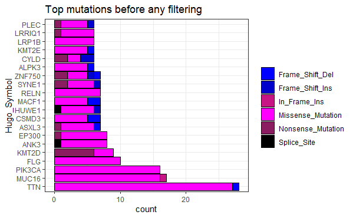

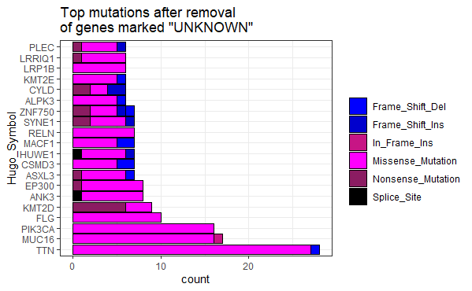

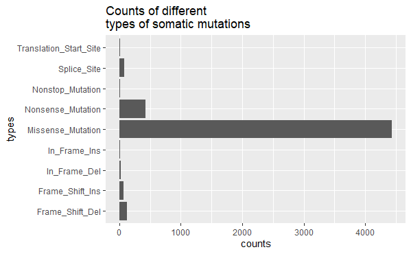

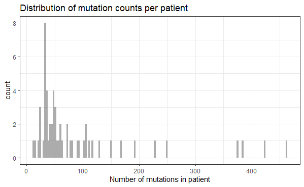

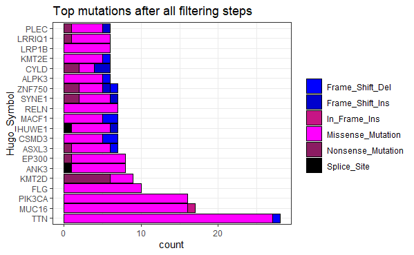

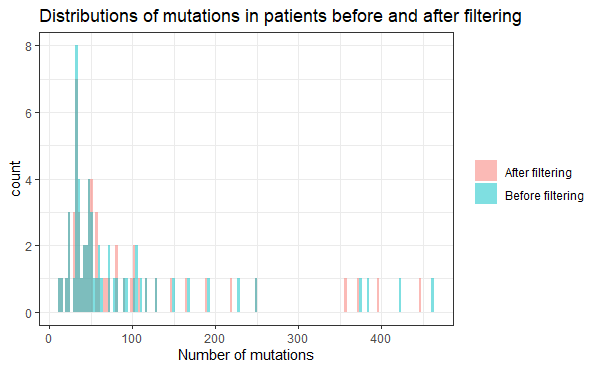

```
[1] ".."
[1] "saving plot..."
[1] "Cohort_overlap_venn_diagram.png"
[1] "./output/imageTemp/graphicCohort_overlap_venn_diagram.png"
[1] "Venn diagram complete."

In bang for buck analysis...[1] "..done\n"
```

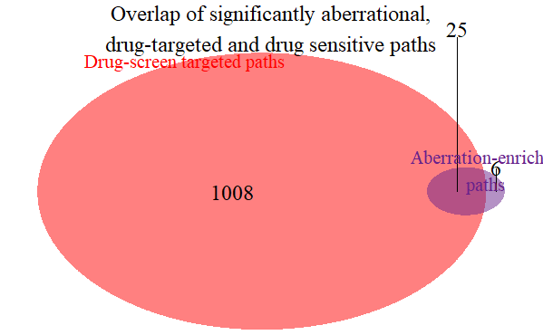

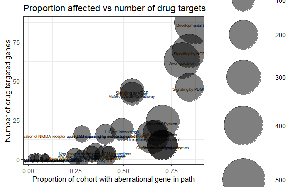

```r
study <- autoRunFromSettings(study)
```

```r
saveStudy(study)
```

[output not shown]

[output cut: 310 more lines]

```
 list to:       settings.txt

Main file path: ./output/study_hnscc_hpv_positive/results/overlap_analysis/settings
[1] "basic_overlap"          "defaultSummaryTable"
[3] "functionalPathAnalysis" "combinedAberrations"
  basic_overlap matrix/data frame to:       basic_overlap.txt
  defaultSummaryTable matrix/data frame to:     defaultSummaryTable.txt
  functionalPathAnalysis matrix/data frame to:      functionalPathAnalysis.txt
  combinedAberrations matrix/data frame to:     combinedAberrations.txt

</saveSummary()>

</saveSummary()>

</saveSummary()>
```

## Inspecting Output, HPV Positive Patients

Output is generated in `output/study_hnscc_hpv_positive/results/overlap_analysis`. The relevant files are:

`Aberrationally enriched, containing drug targets.txt` - Light pathway file

```r
lightPaths <- read.delim("output/study_hnscc_hpv_positive/results/overlap_analysis/Aberrationally enriched, containing drug targets.txt", sep="\t")
DT::datatable(lightPaths)
```

|  | path.number | path_id | full_path_length.x | testable_path_length.x | drug_targeted_genes | proportion_drug_targeted | full_path_length.y | testable_path_length.y | aberrational_genes | proportion_aberrational | proportion_of_cohort_w_aberrational_gene_in_path | Num_patient_with_aberrational_gene_.s._in_path | count_of_aberrational_genes_in_path_cross_cohort | max_in_one_gene | min_in_one_gene | hyperg_p_value | hyperg_p_w_FDR |
| --- | --- | --- | --- | --- | --- | --- | --- | --- | --- | --- | --- | --- | --- | --- | --- | --- | --- |
| 1 | 1 | Signaling by FGFR4 mutants | 1 | 1 | 1 | 1 | 1 | 1 | 1 | 1 | 0.0175438596491228 | 1 | 1 | 1 | 1 | 0 | 0 |
| 2 | 2 | t(4;14) translocations of FGFR3 | 1 | 1 | 1 | 1 | 1 | 1 | 1 | 1 | 0.087719298245614 | 5 | 5 | 5 | 5 | 0 | 0 |
| 3 | 3 | Inhibition of Signaling by Overexpressed EGFR | 2 | 2 | 1 | 0.5 | 2 | 2 | 2 | 1 | 0.0526315789473684 | 3 | 3 | 2 | 1 | 0 | 0 |
| 4 | 4 | Regulation of PAK-2p34 activity by PS-GAP/RHG10 | 2 | 2 | 1 | 0.5 | 2 | 2 | 2 | 1 | 0.0350877192982456 | 2 | 2 | 1 | 1 | 0 | 0 |
| 5 | 5 | phospho-PLA2 pathway | 2 | 2 | 1 | 0.5 | 2 | 2 | 2 | 1 | 0.087719298245614 | 5 | 5 | 3 | 2 | 0 | 0 |
| 6 | 6 | Activation of NMDA receptor upon glutamate binding and postsynaptic events | 39 | 39 | 16 | 0.41025641025641 | 39 | 39 | 19 | 0.487179487179487 | 0.280701754385965 | 16 | 24 | 3 | 0 | 7.24396760856116e-05 | 0.030779381336147 |
| 7 | 7 | VEGFA-VEGFR2 Pathway | 105 | 105 | 42 | 0.4 | 105 | 105 | 43 | 0.40952380952381 | 0.543859649122807 | 31 | 69 | 15 | 0 | 5.51200975729138e-06 | 0.00365230617381266 |
| 8 | 8 | Signaling by VEGF | 113 | 113 | 44 | 0.389380530973451 | 113 | 113 | 44 | 0.389380530973451 | 0.543859649122807 | 31 | 70 | 15 | 0 | 2.10028151110819e-05 | 0.0104760321846875 |
| 9 | 9 | Signaling by PDGF | 184 | 184 | 46 | 0.25 | 184 | 184 | 65 | 0.353260869565217 | 0.842105263157895 | 48 | 111 | 15 | 0 | 1.82858602993941e-05 | 0.0095354208908399 |
| 10 | 10 | Signalling by NGF | 287 | 287 | 69 | 0.240418118466899 | 287 | 287 | 93 | 0.32404181184669 | 0.842105263157895 | 48 | 138 | 15 | 0 | 2.61551699363149e-05 | 0.0125024018879365 |

[output cut: 15 more lines]

```r
NA
```

`Aberration enriched, not drug targeted.txt` - Dark pathway file

```r
darkPaths <- read.delim("output/study_hnscc_hpv_positive/results/overlap_analysis/Aberration enriched, not drug targeted.txt", sep = "\t")
DT::datatable(darkPaths)
```

|  | path_id | full_path_length | testable_path_length | aberrational_genes | proportion_aberrational | proportion_of_cohort_w_aberrational_gene_in_path | Num_patient_with_aberrational_gene_.s._in_path | count_of_aberrational_genes_in_path_cross_cohort | max_in_one_gene | min_in_one_gene | hyperg_p_value | hyperg_p_w_FDR |
| --- | --- | --- | --- | --- | --- | --- | --- | --- | --- | --- | --- | --- |
| ABH3 mediated Reversal of Alkylation Damage | ABH3 mediated Reversal of Alkylation Damage | 1 | 1 | 1 | 1 | 0.0175438596491228 | 1 | 1 | 1 | 1 | 0 | 0 |
| Acrosome Reaction | Acrosome Reaction | 1 | 1 | 1 | 1 | 0.0175438596491228 | 1 | 1 | 1 | 1 | 0 | 0 |
| Biosynthesis of A2E, implicated in retinal degradation | Biosynthesis of A2E, implicated in retinal degradation | 1 | 1 | 1 | 1 | 0.0175438596491228 | 1 | 1 | 1 | 1 | 0 | 0 |
| Tandem pore domain halothane-inhibited K+ channel (THIK) | Tandem pore domain halothane-inhibited K+ channel (THIK) | 1 | 1 | 1 | 1 | 0.0350877192982456 | 2 | 2 | 2 | 2 | 0 | 0 |
| Laminin interactions | Laminin interactions | 23 | 23 | 14 | 0.608695652173913 | 0.245614035087719 | 14 | 19 | 3 | 0 | 1.3061813644244e-05 | 0.00788673108890875 |
| Collagen biosynthesis and modifying enzymes | Collagen biosynthesis and modifying enzymes | 64 | 64 | 27 | 0.421875 | 0.315789473684211 | 18 | 33 | 3 | 0 | 0.000111965801883773 | 0.0428165125675568 |

# Running HPV negative patients

We can reuse the settings object, specifying our HPV negative patients mutation file:

```r
settings$somatic_mutation_aberration_summary$`Select a .maf file containing the data set to be analyzed.` <- "data/TCGA.HNSC.HPV-negative.maf"

study = getStudyObject(study.name="hnscc_hpv_negative", geneIdentifierType="HUGO", path_detail = path_detail, settings = settings)
```

```
[1] "Inside loadSettings()  ... "
```

```
Loading the default summary table settings
```

```
Loading objects:
  defaultSummaryTableSettings
```

```r
study <- loadBasicArms(study)
```

```
Loading basic arms...

Setting arm named ' functional_drug_screen_summary '...  .. arm set.

Setting arm named ' somatic_mutation_aberration_summary '...  .. arm set.

Setting arm named ' arbitrary_gene_data_input '...  .. arm set.

Setting arm named ' overlap_analysis '...  .. arm set.
```

```
Settings were found for these intput arms:
somatic_mutation_aberration_summary functional_drug_screen_summary
[1] "somatic_mutation_aberration_summary"
[1] "Running somatic mutations processing from saved settings"

Main interface for processing somatic mutation data

Loading file: data/TCGA.HNSC.HPV-negative.maf

 12771 rows read in from file.
```

```
This/these column(s) name(s) not found:
Chrom, Ncbi_Build, Dbsnp_Rs, Dbsnp_Val_Status
..attempting correction by making everything in column names uppercase.This/these column(s) name(s) not found:
Chrom, Ncbi_Build, Dbsnp_Rs, Dbsnp_Val_Status
..attempting correction by making everything in column names uppercase.
The column name 'Chromosome' was changed to 'Chrom'
```

[output not shown]

[output cut: 123 more lines]

```
[1] "matrix"
 .3.5  st4.3.6
targetMatrix(): genes from current set that are found the pathways:  3148
 st5.5.6: basic path info st5.5.7: general paths affected info st5.5.8: min max and freq info st5.5.9: sig tests.. Hypergeometric test .. [1] "Regular return from pathway analysis..."

..Producing general summary of path coverage..done..

Path analysis for somatic mutation data complete

Reporting distributions of  Before filtering and After filtering ......done

Returning from somatic mutation analysis arm
[1] "functional_drug_screen_summary"

These are the columns of data available:
```

|  | targets |
| --- | --- |
| 1 | RAF1 |
| 2 | EGFR |
| 3 | BRAF |
| 4 | SLAMF7 |
| 5 | TUBB3 |
| 6 | TUBB |

```
In the input file, 654 unique gene symbols were found
Getting Path_Detail object from Study object ..

Getting HUGO symbols from Path_Detail reference calss object...
[1] "Correcting by HGNChelper"

 2 gene symbols were not found in the approved HUGO symbols.
Checking previously made corrections...
0 symbols could be corrected using previous symbol corrections.
[1] "Coverage analysis: "
[1] "Inside summaryTable()"

Checking coverage ...

Adding coverage analysis...
```

[output cut: 179 more lines]

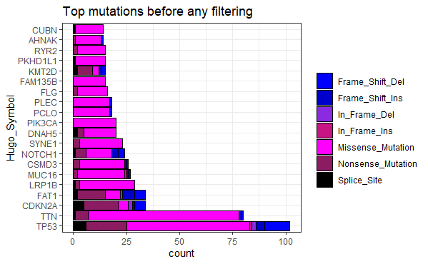

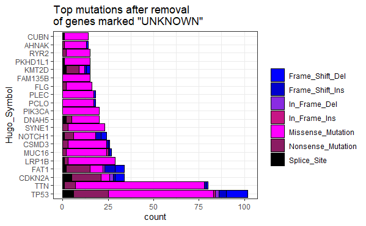

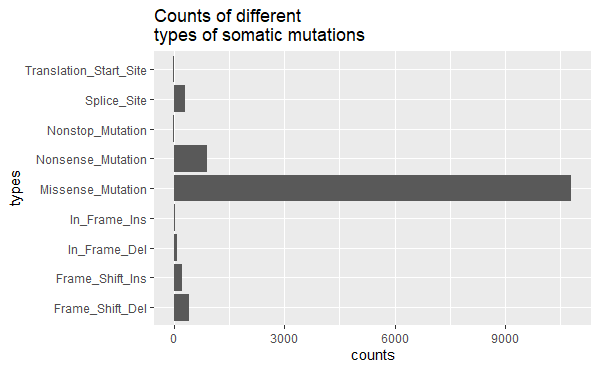

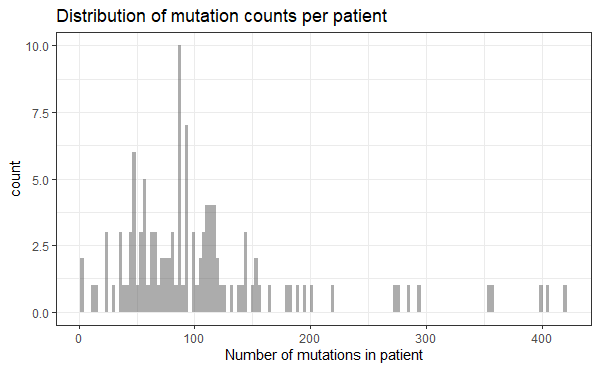

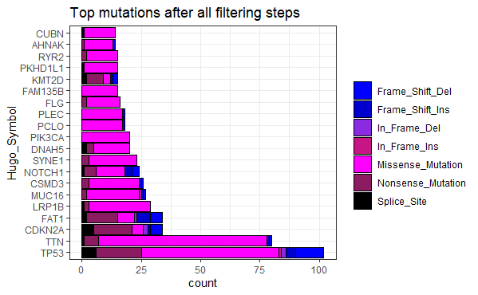

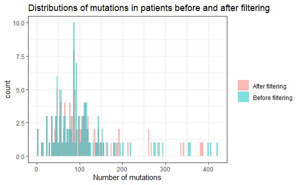

```
[1] ".."
[1] "saving plot..."
[1] "Cohort_overlap_venn_diagram.png"
[1] "./output/imageTemp/graphicCohort_overlap_venn_diagram.png"
[1] "Venn diagram complete."

In bang for buck analysis...[1] "..done\n"
```

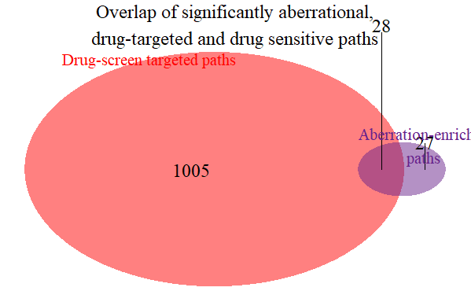

```r
study <- autoRunFromSettings(study)
```

```r
saveStudy(study)
```

[output not shown]

[output cut: 209 more lines]

```
  patient cohort aberrational_and_targeted.png
Copying to file ./output/study_hnscc_hpv_negative/results/overlap_analysis/imageSlots/graphicpatient cohort aberrational_and_targeted.png
 Single value vector to:        patient cohort aberrational_and_targeted.png.txt

</saveSummary()>
  Aberration enriched, not drug targeted matrix/data frame to:      Aberration enriched, not drug targeted.txt
  Pathway overlaps of genes in aberration enriched, not drug targeted paths matrix/data frame to:       Pathway overlaps of genes in aberration enriched, not drug targeted paths.txt
  Aberrationally enriched, containing drug targets matrix/data frame to:        Aberrationally enriched, containing drug targets.txt
  Drug targeted, not aberrationally enriched matrix/data frame to:      Drug targeted, not aberrationally enriched.txt
  Paths containing drug-sensitive genes Single value vector to:     Paths containing drug-sensitive genes.txt
  Enriched for aberration and enriched for sensitive drug targets matrix/data frame to:     Enriched for aberration and enriched for sensitive drug targets.txt
  Aberration enriched, containing sensitive targets matrix/data frame to:       Aberration enriched, containing sensitive targets.txt
  combined_aberrations_summary list to:     combined_aberrations_summary.txt

Main file path: ./output/study_hnscc_hpv_negative/results/overlap_analysis/combined_aberrations_summary
```

## Inspecting the output, HPV-Negative

Output is generated in `output/study_hnscc_hpv_negative/results/overlap_analysis`. The relevant files are:

`Aberrationally enriched, containing drug targets.txt` - Light pathway file

```r
lightPaths <- read.delim("output/study_hnscc_hpv_negative/results/overlap_analysis/Aberrationally enriched, containing drug targets.txt", sep="\t")
DT::datatable(lightPaths)
```

|  | path.number | path_id | full_path_length.x | testable_path_length.x | drug_targeted_genes | proportion_drug_targeted | full_path_length.y | testable_path_length.y | aberrational_genes | proportion_aberrational | proportion_of_cohort_w_aberrational_gene_in_path | Num_patient_with_aberrational_gene_.s._in_path | count_of_aberrational_genes_in_path_cross_cohort | max_in_one_gene | min_in_one_gene | hyperg_p_value | hyperg_p_w_FDR |
| --- | --- | --- | --- | --- | --- | --- | --- | --- | --- | --- | --- | --- | --- | --- | --- | --- | --- |
| 1 | 1 | Signaling by FGFR1 amplification mutants | 1 | 1 | 1 | 1 | 1 | 1 | 1 | 1 | 0.00847457627118644 | 1 | 1 | 1 | 1 | 0 | 0 |
| 2 | 2 | Signaling by FGFR2 amplification mutants | 1 | 1 | 1 | 1 | 1 | 1 | 1 | 1 | 0.0169491525423729 | 2 | 2 | 2 | 2 | 0 | 0 |
| 3 | 3 | Signaling by FGFR4 mutants | 1 | 1 | 1 | 1 | 1 | 1 | 1 | 1 | 0.00847457627118644 | 1 | 1 | 1 | 1 | 0 | 0 |
| 4 | 4 | t(4;14) translocations of FGFR3 | 1 | 1 | 1 | 1 | 1 | 1 | 1 | 1 | 0.00847457627118644 | 1 | 1 | 1 | 1 | 0 | 0 |
| 5 | 5 | Inhibition of HSL | 2 | 2 | 1 | 0.5 | 2 | 2 | 2 | 1 | 0.0254237288135593 | 3 | 3 | 2 | 1 | 0 | 0 |
| 6 | 6 | Inhibition of Signaling by Overexpressed EGFR | 2 | 2 | 1 | 0.5 | 2 | 2 | 2 | 1 | 0.0338983050847458 | 4 | 5 | 3 | 2 | 0 | 0 |
| 7 | 7 | Neurophilin interactions with VEGF and VEGFR | 4 | 4 | 2 | 0.5 | 4 | 4 | 4 | 1 | 0.0593220338983051 | 7 | 7 | 4 | 1 | 0 | 0 |
| 8 | 8 | PDE3B signalling | 2 | 2 | 1 | 0.5 | 2 | 2 | 2 | 1 | 0.0254237288135593 | 3 | 3 | 2 | 1 | 0 | 0 |
| 9 | 9 | FGFR1c and Klotho ligand binding and activation | 3 | 3 | 1 | 0.333333333333333 | 3 | 3 | 3 | 1 | 0.0423728813559322 | 5 | 5 | 2 | 1 | 0 | 0 |
| 10 | 10 | Apoptotic cleavage of cellular proteins | 38 | 38 | 8 | 0.210526315789474 | 38 | 38 | 28 | 0.736842105263158 | 0.389830508474576 | 46 | 62 | 12 | 0 | 1.14730223665926e-05 | 0.00347920460449755 |

[output cut: 18 more lines]

```r
NA
```

`Aberration enriched, not drug targeted.txt` - Dark pathway file

```r
darkPaths <- read.delim("output/study_hnscc_hpv_negative/results/overlap_analysis/Aberration enriched, not drug targeted.txt", sep = "\t")
DT::datatable(darkPaths)
```

|  | path_id | full_path_length | testable_path_length | aberrational_genes | proportion_aberrational | proportion_of_cohort_w_aberrational_gene_in_path | Num_patient_with_aberrational_gene_.s._in_path | count_of_aberrational_genes_in_path_cross_cohort | max_in_one_gene | min_in_one_gene | hyperg_p_value | hyperg_p_w_FDR |
| --- | --- | --- | --- | --- | --- | --- | --- | --- | --- | --- | --- | --- |
| ABH3 mediated Reversal of Alkylation Damage | ABH3 mediated Reversal of Alkylation Damage | 1 | 1 | 1 | 1 | 0.00847457627118644 | 1 | 1 | 1 | 1 | 0 | 0 |
| Abnormal conversion of 2-oxoglutarate to 2-hydroxyglutarate | Abnormal conversion of 2-oxoglutarate to 2-hydroxyglutarate | 1 | 1 | 1 | 1 | 0.00847457627118644 | 1 | 1 | 1 | 1 | 0 | 0 |
| Aromatic amines can be N-hydroxylated or N-dealkylated by CYP1A2 | Aromatic amines can be N-hydroxylated or N-dealkylated by CYP1A2 | 1 | 1 | 1 | 1 | 0.00847457627118644 | 1 | 1 | 1 | 1 | 0 | 0 |
| Biosynthesis of A2E, implicated in retinal degradation | Biosynthesis of A2E, implicated in retinal degradation | 1 | 1 | 1 | 1 | 0.00847457627118644 | 1 | 1 | 1 | 1 | 0 | 0 |
| C6 deamination of adenosine | C6 deamination of adenosine | 2 | 2 | 2 | 1 | 0.0169491525423729 | 2 | 2 | 1 | 1 | 0 | 0 |
| COX reactions | COX reactions | 1 | 1 | 1 | 1 | 0.00847457627118644 | 1 | 1 | 1 | 1 | 0 | 0 |
| Conjugation of benzoate with glycine | Conjugation of benzoate with glycine | 5 | 5 | 5 | 1 | 0.0847457627118644 | 10 | 10 | 6 | 1 | 0 | 0 |
| Conjugation of phenylacetate with glutamine | Conjugation of phenylacetate with glutamine | 2 | 2 | 2 | 1 | 0.0593220338983051 | 7 | 7 | 6 | 1 | 0 | 0 |
| Formation of editosomes by ADAR proteins | Formation of editosomes by ADAR proteins | 2 | 2 | 2 | 1 | 0.0169491525423729 | 2 | 2 | 1 | 1 | 0 | 0 |
| GABA synthesis | GABA synthesis | 2 | 2 | 2 | 1 | 0.0254237288135593 | 3 | 3 | 2 | 1 | 0 | 0 |

[output cut: 17 more lines]